# SDG_Final 2 May.08.2023

Huseyn Panahov

2023-05-07

# Libraries

```r
library(readxl) #for reading excel files
library(openxlsx)
library(dplyr) #for dataset controls/analysis
library(ggplot2) # for visualizations
library(plotly)
library(readr)
library(tidyr)
library(lavaan)
library(semPlot)
library(corrplot)
library(QuantPsyc)
```

# Loading the data

Our new data frame includes both the Human Capital Index estimated by the World Bank Group and the synthetic Infrastructure Index that we manually constructed based on the following 5 indicators from the UN SDG Report 20222:  
- sdg6_water: Population using at least basic drinking water services (%)  
- sdg6_sanita: Population using at least basic sanitation services (%)  
- sdg8_elecac: Population with access to electricity (%)  
- sdg9_intuse: Population using the internet (%)  
- sdg11_transport: The percentage of the surveyed population that responded “satisfied” to the question “In the city or area where you live, are you satisfied or dissatisfied with the public transportation systems?”.

```r
file_path <- "SDG_HCI_Data.xlsx"
data <- read.xlsx(file_path, sheet = 1)
head(data)
```

```
##       Country      Region Income.Group  sdg_ind     sdg1     sdg2     sdg5
## 1 Afghanistan E_Euro_Asia          LIC 52.18278 91.41714 51.58329 21.72500
## 2     Albania E_Euro_Asia         UMIC 71.51276 93.00600 59.90357 53.16600
## 3     Algeria        MENA         LMIC 71.47117 97.33900 58.43457 53.40250
## 4      Angola      Africa         LMIC 50.94025 13.03700 55.80837 50.27925
## 5   Argentina         LAC         UMIC 72.72849 96.43050 67.52425 81.23567
## 6     Armenia E_Euro_Asia         UMIC 70.72178 86.57350 60.45800 57.85500
##      sdg13 sdg6_water sdg6_sanit sdg7_electr sdg8_bank sdg9_internet
## 1 98.83733     58.485     45.183      97.470     7.492        16.564
## 2 88.48200     91.780     99.224     100.000    34.799        71.616
## 3 88.55367     90.728     84.457      99.450    37.801        62.065
## 4 96.80800     28.613     46.467      40.231    23.172        34.560
## 5 88.16100     98.373     94.926     100.000    44.248        85.174
## 6 90.94700     99.952     93.286     100.000    43.216        75.982
##   sdg9_mobile sdg9_lpi sdg11_transport sdg17_statperf   hci_ind  infr_ind
## 1      18.068    9.409          21.104         33.008 0.4002841 0.5465587
## 2      61.566   31.545          43.831         67.177 0.6342509 0.9192261
## 3      89.675   37.318          42.208         40.199 0.5345564 0.8555009
## 4      20.060   11.682          17.857         39.928 0.3624054 0.3277658
## 5      71.647   53.364          53.571         52.795 0.6021447 0.9497555
## 6      78.500   40.182          42.208         76.303 0.5789988 0.9358095
```

# Correlation Plot

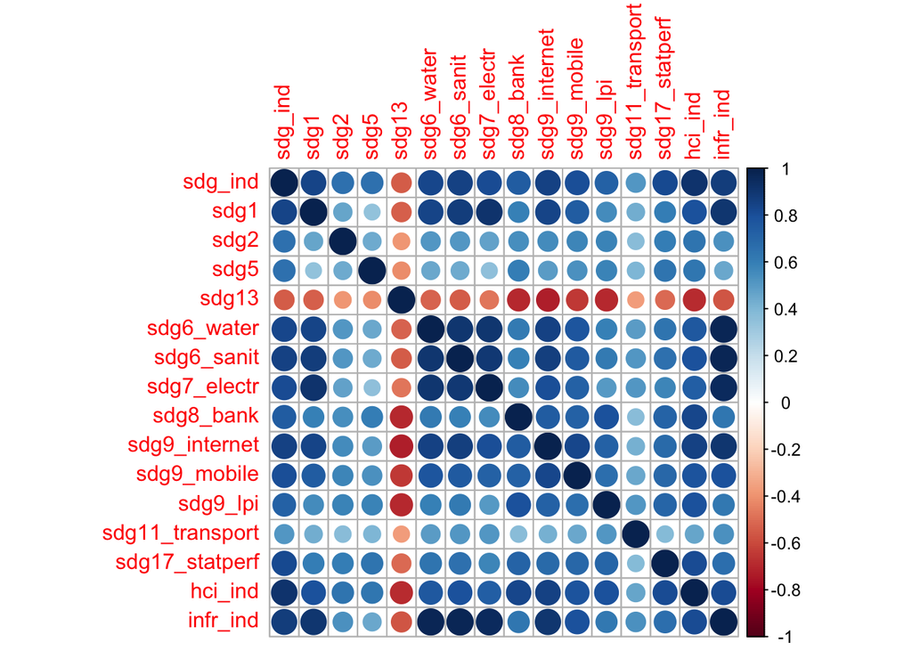

```r
# Identify numeric columns
numeric_columns <- sapply(data, is.numeric)

# A data frame with only numeric variables
numeric_data <- data[, numeric_columns]

# Correlation matrix for the numeric variables
cor_matrix <- cor(numeric_data, use = "complete.obs")

# A correlation matrix plot
corrplot(cor_matrix, method = "circle")
```

# Multiple Regression model

```r
# Fit the multiple linear regression model
lm_model <- lm(sdg_ind ~ hci_ind + infr_ind + sdg17_statperf, data = data)

# Print the summary of the model
summary(lm_model)
```

```
##
## Call:
## lm(formula = sdg_ind ~ hci_ind + infr_ind + sdg17_statperf, data = data)
##
## Residuals:
##     Min      1Q  Median      3Q     Max
## -9.1985 -1.6983 -0.0203  1.8949  6.5473
##
## Coefficients:
##                Estimate Std. Error t value Pr(>|t|)
## (Intercept)    35.11304    1.09261  32.137  < 2e-16 ***
## hci_ind        27.95495    3.89637   7.175 4.14e-11 ***
## infr_ind       13.28677    1.52356   8.721 8.22e-15 ***
## sdg17_statperf  0.12007    0.02137   5.618 1.04e-07 ***
## ---
## Signif. codes:  0 '***' 0.001 '**' 0.01 '*' 0.05 '.' 0.1 ' ' 1
##
## Residual standard error: 2.975 on 137 degrees of freedom
## Multiple R-squared:  0.9102, Adjusted R-squared:  0.9082
## F-statistic: 462.6 on 3 and 137 DF,  p-value: < 2.2e-16
```

**Observations:**  
In order to estimate the impact of each individual variable on the SDG Index, we can look at the beta coefficients. The standardized beta coefficients allow us to compare the effects of the variables on the same scale, regardless of the units of measurement.

```r
# Calculate standardized beta coefficients
beta_coefficients <- lm.beta(lm_model)

cat("Coefficients for SDG Index:\n")
```

```
## Coefficients for SDG Index:
```

```r
print(beta_coefficients)
```

```
##        hci_ind       infr_ind sdg17_statperf
##      0.4031002      0.3845881      0.2459228
```

**Observations:**  
Both Human Capital and Infrastructure are statistically significant. They’re both fundamentally important factors when we look at international development metrics. However, Human Capital there is a slightly stronger dependancy between the overall SDG Index of a country and Human Capital Index, than with Infrastructure Index.

# Multiple regression:

To look at the interaction with SDG 1 (No Poverty), SDG 5 (Gender Equality), SDG 13 (Climate Action).

```
## Response sdg1 :
##
## Call:
## lm(formula = sdg1 ~ hci_ind + infr_ind + sdg17_statperf, data = data)
##
## Residuals:
##     Min      1Q  Median      3Q     Max
## -27.418  -4.789  -0.778   5.681  49.178
##
## Coefficients:
##                Estimate Std. Error t value Pr(>|t|)
## (Intercept)    -9.17520    4.59414  -1.997 0.047789 *
## hci_ind        55.96758   16.38317   3.416 0.000836 ***
## infr_ind       84.95445    6.40616  13.261  < 2e-16 ***
## sdg17_statperf -0.18741    0.08987  -2.085 0.038891 *
## ---
## Signif. codes:  0 '***' 0.001 '**' 0.01 '*' 0.05 '.' 0.1 ' ' 1
##
## Residual standard error: 12.51 on 137 degrees of freedom
## Multiple R-squared:  0.8396, Adjusted R-squared:  0.8361
## F-statistic: 239.1 on 3 and 137 DF,  p-value: < 2.2e-16
##
##
## Response sdg5 :
##
## Call:
## lm(formula = sdg5 ~ hci_ind + infr_ind + sdg17_statperf, data = data)
##
## Residuals:
##     Min      1Q  Median      3Q     Max
## -29.313  -8.000   0.042   8.157  34.079
##
## Coefficients:
##                 Estimate Std. Error t value Pr(>|t|)
## (Intercept)     21.38845    4.49264   4.761 4.84e-06 ***
## hci_ind         56.78576   16.02122   3.544 0.000539 ***
## infr_ind       -10.92816    6.26463  -1.744 0.083328 .
## sdg17_statperf   0.30357    0.08788   3.454 0.000735 ***
## ---
## Signif. codes:  0 '***' 0.001 '**' 0.01 '*' 0.05 '.' 0.1 ' ' 1
```

[output cut: 12 more lines]

```
##     Min      1Q  Median      3Q     Max
## -70.573  -3.813   2.665   8.691  27.330
##
## Coefficients:
##                 Estimate Std. Error t value Pr(>|t|)
## (Intercept)     139.8737     5.7301  24.410  < 2e-16 ***
## hci_ind        -117.3525    20.4340  -5.743 5.75e-08 ***
## infr_ind         -2.5644     7.9901  -0.321    0.749
## sdg17_statperf    0.1596     0.1121   1.424    0.157
## ---
## Signif. codes:  0 '***' 0.001 '**' 0.01 '*' 0.05 '.' 0.1 ' ' 1
##
## Residual standard error: 15.6 on 137 degrees of freedom
## Multiple R-squared:  0.4767, Adjusted R-squared:  0.4652
## F-statistic:  41.6 on 3 and 137 DF,  p-value: < 2.2e-16
```

*Note: some of the relationships are not statistically significant*

**The Beta coefficients:**

```
## Coefficients for SDG 1, No Poverty:
```

```
##        hci_ind       infr_ind sdg17_statperf
##      0.2564407      0.7813734     -0.1219724
```

```
##
## Coefficients for SDG 5, Gender Equality:
```

```
##        hci_ind       infr_ind sdg17_statperf
##      0.4877793     -0.1884313      0.3703909
```

```
##
## Coefficients for SDG 13, Climate Action:
```

```
##        hci_ind       infr_ind sdg17_statperf
##    -0.77873257    -0.03415908     0.15041170
```

**Observations:**

I look at the absolute values of the coefficients to interpret their respective impact on the Sustainable Development Goal. As we can see, there is a much stronger dependency between infrastructure and SDG 1, whereas SDG 5 and SDG 13 have stronger dependencies on Human Capital.